### Total Cases and Total Deaths

These show the cumulative total of cases and deaths by day. I have also denoted the current cumulative totals. These total values are important; however they are not helpful for figuring out whether the pandemic is slowing down or growing as it is difficult to see trends in cumulative curves like these.

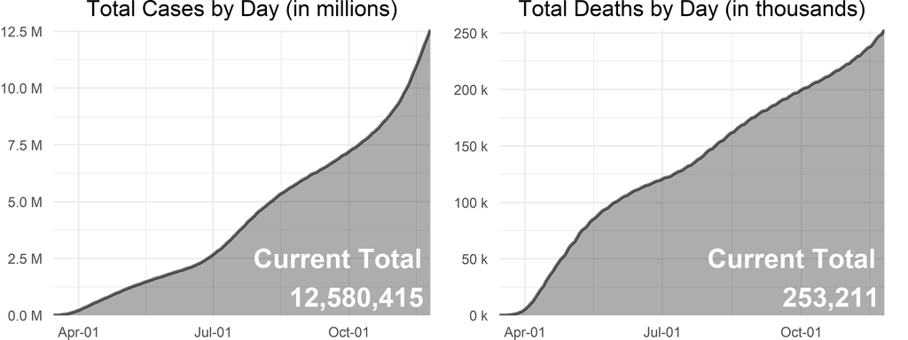

### New Cases

Looking at new cases each day can help us see if the pandemic is slowing. A decreasing number of new cases per day is evidence that the pandemic is slowing down.

There can be a lot of variability in the daily case totals due to a variety of variables. One example is the availability of tests; cases will go down if there is a scarcity of tests and rise dramatically when more tests become available. One way to help get a better sense of the overall trend is by smoothing the data using a moving average.

There is also a cyclical nature to the daily new cases with counts often being lower on weekends and higher on weekdays.

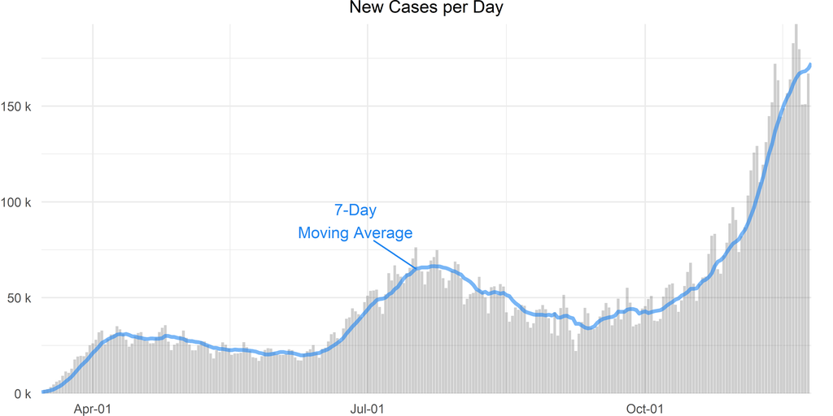

### New Deaths and Death Percentage

COVID-19 is much deadlier than the common flu. One way to measure the impact is to look at the death percentage, which is the total number of deaths divided by the total number of cases.

A big concern during April was that the death percentage was continually increasing, even when actual deaths per day were not increasing. Starting in early May the death percentage started to plateau around 6%. At the end of May, the death percentage starts curving downward as deaths per day continued to decrease as new cases per days continued to plateau and then increase. In July, daily deaths started to increase.

Similar to new cases there is a cyclical nature to spikes in new cases. These spikes may be due to reporting times where counts on weekdays are often higher than those on weekends. Spikes also occur when previous deaths are re-assigned as COVID-19 related deaths, such as counting nursing home deaths and/or pneumonia deaths. In late June, states began to add probable deaths to the death count: Delaware (June 23rd), New Jersey (June 25th), and New York (June 30th). On July 27th, Texas announced a change in the way it counts deaths.

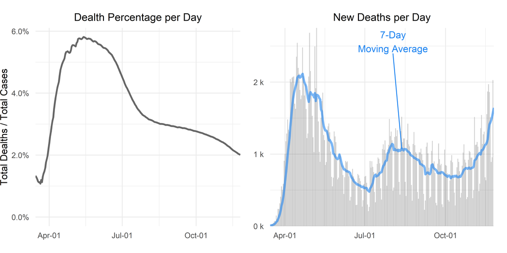

### Values for Past 14 Days

The actual values for the previous 14 days are detailed in the table below.

| Date | Total Cases | Total Deaths | New Cases | New Cases 7-MA | New Deaths | New Deaths 7-MA | Death Percentage |
| --- | --- | --- | --- | --- | --- | --- | --- |
| Wed, Nov 25, 2020 | 12,580,415 | 253,211 | 182,931 | 172,443 | 2,285 | 1,643 | 2.013% |
| Tue, Nov 24, 2020 | 12,397,484 | 250,926 | 167,012 | 169,735 | 2,029 | 1,584 | 2.024% |
| Mon, Nov 23, 2020 | 12,230,472 | 248,897 | 150,975 | 168,265 | 956 | 1,516 | 2.035% |
| Sun, Nov 22, 2020 | 12,079,497 | 247,941 | 150,836 | 167,964 | 892 | 1,471 | 2.053% |
| Sat, Nov 21, 2020 | 11,928,661 | 247,049 | 179,714 | 167,050 | 1,512 | 1,440 | 2.071% |
| Fri, Nov 20, 2020 | 11,748,947 | 245,537 | 192,805 | 164,739 | 1,862 | 1,411 | 2.090% |
| Thu, Nov 19, 2020 | 11,556,142 | 243,675 | 182,832 | 161,782 | 1,971 | 1,328 | 2.109% |
| Wed, Nov 18, 2020 | 11,373,310 | 241,704 | 163,975 | 157,378 | 1,869 | 1,209 | 2.125% |
| Tue, Nov 17, 2020 | 11,209,335 | 239,835 | 156,722 | 154,639 | 1,555 | 1,162 | 2.140% |
| Mon, Nov 16, 2020 | 11,052,613 | 238,280 | 148,868 | 150,990 | 637 | 1,135 | 2.156% |
| Sun, Nov 15, 2020 | 10,903,745 | 237,643 | 144,434 | 146,785 | 677 | 1,128 | 2.179% |
| Sat, Nov 14, 2020 | 10,759,311 | 236,966 | 163,540 | 141,906 | 1,312 | 1,100 | 2.202% |
| Fri, Nov 13, 2020 | 10,595,771 | 235,654 | 172,106 | 137,002 | 1,275 | 1,071 | 2.224% |
| Thu, Nov 12, 2020 | 10,423,665 | 234,379 | 152,003 | 130,381 | 1,141 | 1,055 | 2.249% |